# Ebola Outbreak 2014-2016, Perulung study

Author

Damian Jandrasits

Published

June 15, 2023

## Introduction: Ebola

Ebola virus (EBOV) is a member of the filoviridae familiy. Since the infection of EBOV in humans lead to severe hemorrhagic fever, often resulting in death, this virus is classified as a biosafety-level (BSL-) 4 pathogen. Therefore, research on this virus need a high-containment facility, whereas the numbers of these laboratories worldwide are very limited. Although first identified in 1976 in the Democratic Republic of Congo (DRC), the most devastating outbreak of EBOV occurred in 2014-2016 in Western Africa. For more information concerning the prevention and treatment, check out the [World Health Organisation Fact Sheet for Ebola Virus disease](https://www.who.int/news-room/fact-sheets/detail/ebola-virus-disease?gclid=CjwKCAjwsvujBhAXEiwA_UXnAInaIbSPS2j2_LaPjKgzeLeBErnPDoHRlMONWUqqj2cijlr98ycjExoCP8cQAvD_BwE).

How changed the confirmed cases and deaths over time? Which country displayed the most cumulative cases?

For the second dataset, the sex and respiratory symptoms will be compared. What are the proportions of boy and girls experiencing respiratory symptoms? Furthermore, the forced expiratory volume in 1 second (FEV1) will be investigated. How does it depend on other factors?

```r
#load libraries
library(here)
library(tidyverse)
library(lubridate)
library(unibeCols)
library(dplyr)
library(ggplot2)
library(dplyr)
library(hrbrthemes)
library(rstatix)
library(knitr)
```

```r
# Read datasets
ebola <- read_csv("ebola.csv")
peru <- read_csv("perulung_ems.csv")
```

### Summary of confirmed ebola virus cases during the 2014-2016 outbreak in west african countries

As seen in the figure below the west African countries Guinea, Liberia, and Sierra Leone reported the most laboratory-confirmed cases during the 2014-2016 Ebola outbreak. Out of these three countries, Sierra Leone had the most confirmed cases, followed by Guinea and Liberia.

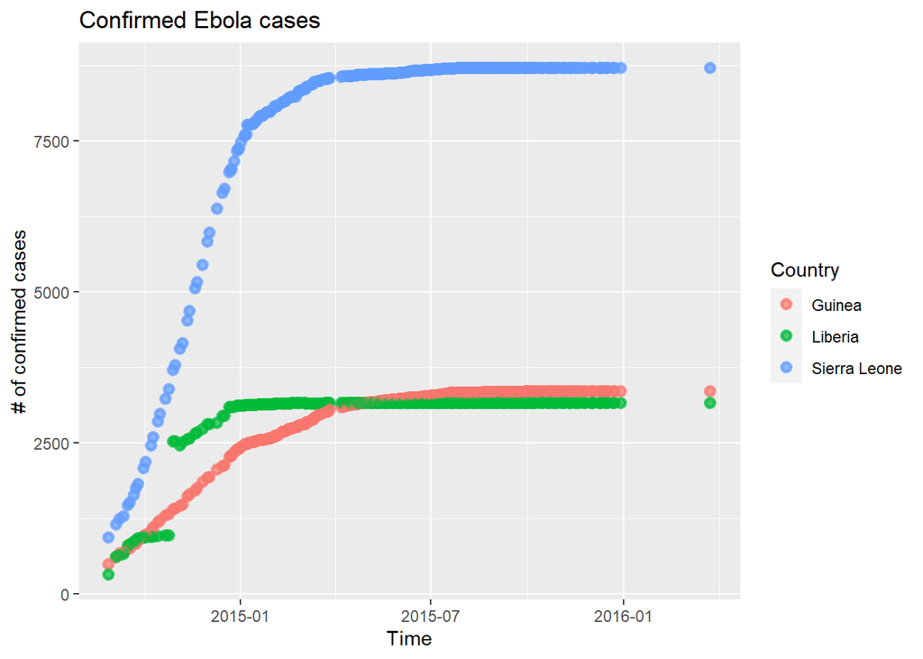

```r
# Process data of the cumulative confirmed cases over time during the outbreak
#| label: fig-cases
#| fig-cap: "Laboratory-confirmed cases of Ebola in Guinea, Liberia and Sierra Leone during the 2014 Ebola virus outbreak."
#| warning: false
#| fig-width: 8
#| fig-height: 4

ebola_countries <- ebola %>% filter(Date <= as.Date("2016-04-01")
                                       & (Country == "Guinea" | Country == "Liberia" | Country == "Sierra Leone"))
plot_ebola_point_v3 <- ggplot(data = ebola_countries,
                              mapping = aes(x = Date, y = Cum_conf_cases, fill = Country, colour = Country)) +
  geom_point(alpha = 0.7, shape = 21, size = 1.5, stroke = 1.5) +
  ggtitle(label = "Confirmed Ebola cases") +
  xlab(label = "Time") +
  ylab(label = "# of confirmed cases")
plot_ebola_point_v3
```

```r
# Descriptive statistics
mean_cases <- mean(ebola_countries$Cum_conf_cases, na.rm =  TRUE)
mean_cases
```

```
[1] 4587.077
```

```r
median_cases <- median(ebola_countries$Cum_conf_cases, na.rm =  TRUE)
median_cases
```

```
[1] 3171.5
```

```r
quart_cases <- quantile(ebola_countries$Cum_conf_cases, probs = c(0.25, 0.5, 0.75),
                     na.rm = TRUE)

quart_cases
```

```
   25%    50%    75%
3150.0 3171.5 8135.0
```

```r
range(ebola_countries$Cum_conf_cases, na.rm = TRUE)
```

```
[1]  322 8704
```

### Summary of confirmed Ebola virus deaths during the 2014-2016 outbreak in west African countries

The figure below shows the confirmed deaths due to the Ebola virus in Guinea, Liberia, and Sierra Leone.

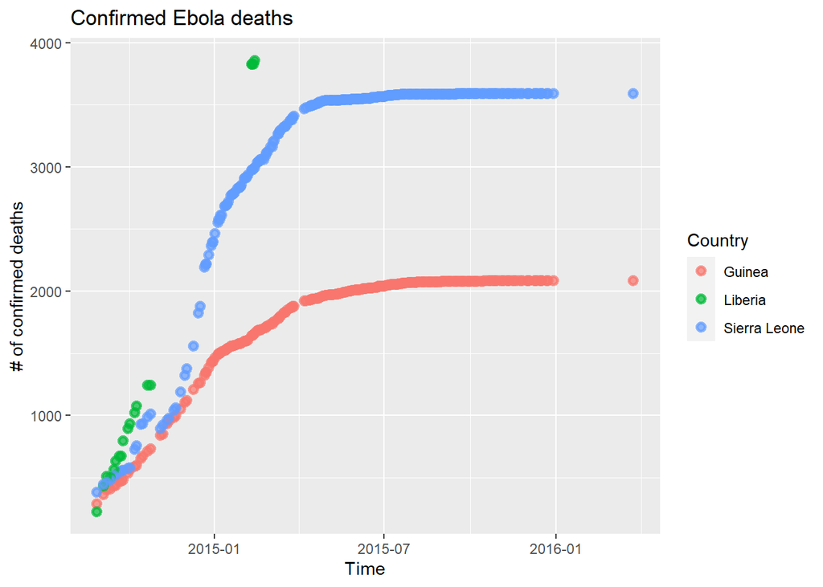

```r
# Process data of the confirmed deaths over time during the outbreak
#| label: fig-deaths
#| fig-cap: "Confirmed deaths of Ebola in Guinea, Liberia and Sierra Leone during the 2014 Ebola virus outbreak."
#| warning: false
#| fig-width: 8
#| fig-height: 4

ebola_countries_deaths <- ebola %>% filter(Date <= as.Date("2016-04-01")
                                       & (Country == "Guinea" | Country == "Liberia" | Country == "Sierra Leone"))
plot_ebola_point_deaths_v1 <- ggplot(data = ebola_countries,
                              mapping = aes(x = Date, y = Cum_conf_death, fill = Country, colour = Country)) +
  geom_point(alpha = 0.7, shape = 21, size = 1.5, stroke = 1.5) +
  ggtitle(label = "Confirmed Ebola deaths") +
  xlab(label = "Time") +
  ylab(label = "# of confirmed deaths")
plot_ebola_point_deaths_v1
```

```r
# Descriptive statistics of confirmed deaths
mean_death <- mean(ebola_countries_deaths$Cum_conf_death, na.rm =  TRUE)
mean_death
```

```
[1] 2412.6
```

```r
median_death <- median(ebola_countries_deaths$Cum_conf_death, na.rm =  TRUE)
median_death
```

```
[1] 2081
```

```r
quart_death <- quantile(ebola_countries_deaths$Cum_conf_death, probs = c(0.25, 0.5, 0.75),
                     na.rm = TRUE)
quart_death
```

```
 25%  50%  75%
1875 2081 3545
```

```r
range(ebola_countries$Cum_conf_death, na.rm = TRUE)
```

```
[1]  225 3858
```

## Total confirmed cases between Guinea, Liberia, and Sierra Leone

```r
ebola3c <- ebola |>
  filter(Date <= as.Date("2016-04-01")
    & (Country == "Guinea" | Country == "Liberia" | Country == "Sierra Leone"))
```

```r
# Mutate country as factor
ebola3cc <- ebola3c %>%
  mutate(Country = factor(Country,labels=c("Guinea", "Liberia","Sierra Leone")))
```

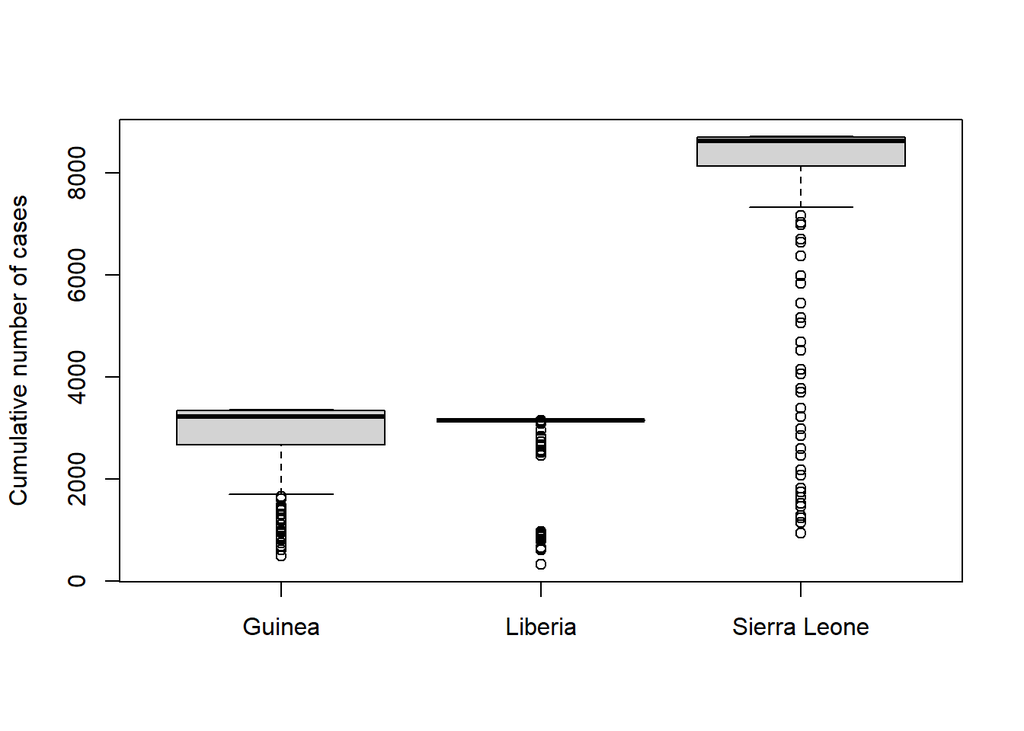

```r
boxplot(ebola3cc$Cum_conf_cases ~ ebola3cc$Country, xlab = "",
        ylab = "Cumulative number of cases")
```

This boxplot shows the cumulative confirmed cases in Guinea, Liberia, and Sierra Leone. The **bold black line** thereby represents the median. Points below the lower whisker are defined as **outliers**. Especially for Sierra Leone, there are a lot of outliers present. This indicates a rapid increase in the confirmed Ebola cases at one point of the outbreak, underlining the enourmous health crisis in this country during that epidemics. Also for Guinea and Liberia, some outliers are seen. This also indicates a rapid increase in the cummulative confirmed cases in these countries at a certain point during the epidemics.

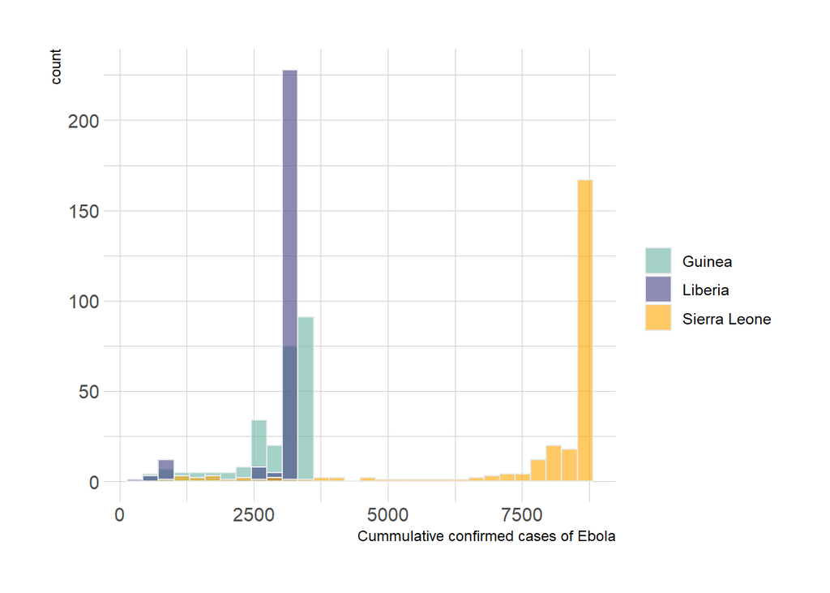

```r
# Represent data
#| label: fig-cumulative-confirmed-cases-in-Guinea,-Liberia,-and-Sierra-Leone
#| fig-cap: "Cumulative confirmed cases during the 2014-2016 Ebola outbreak in the three most affected countries."
#| warning: false
#| fig-width: 8
#| fig-height: 4

p <- ebola3cc %>%
  ggplot( aes(x=Cum_conf_cases, fill=Country)) +
    geom_histogram( color="#e9ecef", alpha=0.6, position = 'identity') +
    scale_fill_manual(values=c("#69b3a2", "#404080","orange" )) +
    theme_ipsum() +
    labs(fill="")  +
  xlab("Cummulative confirmed cases of Ebola")
p
```

## Conclusion

Since this dataset only displays the cumulative cases and death, further analyses are not possible. Therefore, another dataset (Perulung) will be taken for these analyses. I apologize for this circumstance.

# Perulung study

```r
head(peru)
```

```
# A tibble: 6 × 7
     id  fev1   age height   sex respsymptoms asthma_hist
  <dbl> <dbl> <dbl>  <dbl> <dbl>        <dbl> <chr>
1   638  0.64  7.47   118.     1            1 current asthma
2   527  0.68  8.21   113.     0            1 never
3    33  0.81  8.42   121.     0            0 never
4   289  0.81  7.46   109.     0            0 never
5   254  0.82  8.95   128      0            1 current asthma
6   355  0.83  8.48   115      0            1 previous asthma
```

```r
Tab_peru <-  table(peru$sex, peru$respsymptoms)
Tab_peru
```

```
      0   1
  0 254  81
  1 237  64
```

In this study, there are a total of 335 male and 301 female children. It is seen that 254 male and 237 female children did not have respiratory symptoms, while 81 male and 64 female children did experience respiratory symptoms.

```r
n_byresp <- rowSums(Tab_peru)
p_byresp <- Tab_peru["0", "1"] / n_byresp
as.matrix(p_byresp)
```

```
      [,1]
0 0.241791
1 0.269103
```

```r
SE_respsymp <- sqrt(p_byresp * (1 - p_byresp) / n_byresp)


lowerCI_p_respsymp <- p_byresp - qnorm(0.975) * SE_respsymp

upperCI_p_respsymp <- p_byresp + qnorm(0.975) * SE_respsymp

cbind(p_byresp , lowerCI_p_respsymp, upperCI_p_respsymp)
```

```
  p_byresp lowerCI_p_respsymp upperCI_p_respsymp
0 0.241791          0.1959409          0.2876411
1 0.269103          0.2190013          0.3192047
```

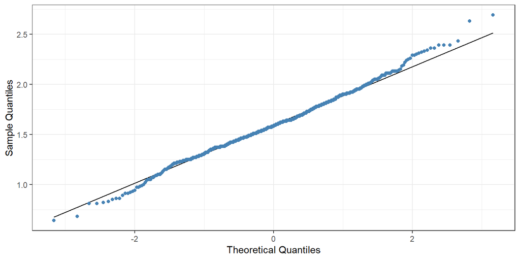

```r
peru %>%
  ggplot(aes(sample = fev1)) +
  geom_qq_line(distribution = stats::qnorm) +
  geom_qq(color = "steelblue", distribution = stats::qnorm) +
  xlab("Theoretical Quantiles") +
  ylab("Sample Quantiles") +
  theme_bw()
```

```r
shapiro_tests <- peru %>%
  shapiro_test(fev1, height, age, sex,id,)

shapiro_tests %>%
  kable(digits = 10)
```

| variable | statistic | p |
| --- | --- | --- |
| age | 0.9766132 | 0.0000000152 |
| fev1 | 0.9946980 | 0.0265679586 |
| height | 0.9939268 | 0.0117939272 |
| id | 0.9545267 | 0.0000000000 |
| sex | 0.6355230 | 0.0000000000 |

```r
cor_matrix <- peru %>%
    dplyr::select(id,fev1,age,height,sex,respsymptoms) %>%
  cor(use = "complete.obs", method = "spearman")

cor_matrix %>%
  kable(digits = 3)
```

|  | id | fev1 | age | height | sex | respsymptoms |
| --- | --- | --- | --- | --- | --- | --- |
| id | 1.000 | -0.024 | -0.044 | -0.003 | 0.028 | 0.013 |
| fev1 | -0.024 | 1.000 | 0.505 | 0.630 | 0.203 | -0.203 |
| age | -0.044 | 0.505 | 1.000 | 0.567 | -0.034 | -0.167 |
| height | -0.003 | 0.630 | 0.567 | 1.000 | 0.014 | -0.111 |
| sex | 0.028 | 0.203 | -0.034 | 0.014 | 1.000 | -0.035 |
| respsymptoms | 0.013 | -0.203 | -0.167 | -0.111 | -0.035 | 1.000 |

Finally, there is a correlation between height and fev1, as well as height and age. The fev1 also correlates with the age, as older children usually have a bigger lung volume. Since taller children also have a higher lung capacity, the fev1 correlates with the height of the children. The sex seems to have a small correlation with the fev1. The presence of any respiratory symptoms have a negative correlation with fev1, since in children with respiratory symptoms, the fev1 is reduced.

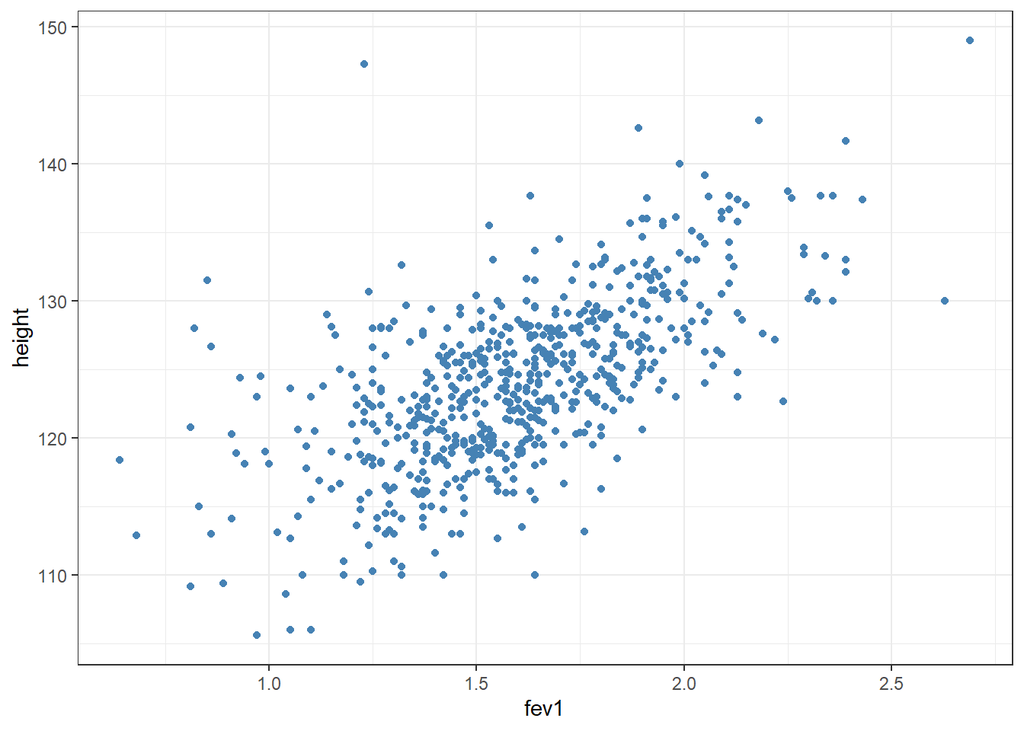

```r
peru %>%
  ggplot(aes(fev1, height)) +
  geom_point(color = "steelblue") + theme_bw()
```

This plot again shows the correlation between the fev1 and the height of the children. The taller the children, the higher is the fev1.